# VITAL-HMB Descriptive and Univariate Analysis

Dr. Bashir Ssuna

30 June 2026

# 1 Overview

This report cleans and describes every variable used in the VITAL-HMB analysis, grouped by clinical domain. The outcome is heavy menstrual bleeding (HMB) by the alkaline hematin test (`HMB calc`). For each domain we give frequency and proportion tables n (%) by HMB status, summary statistics, missingness and its likely mechanism, consistency checks, plots against the outcome, and univariate logistic associations. Tables are built with `gt` and `dplyr` (regressions via `broom`); figures with `ggplot2`.

To run on a new export, change `params$data_file` at the top (Knit with Parameters), or edit the path. The file must be a REDCap label export with `Record ID`, `Event Name` and `HMB calc`.

# 2 Load data and define the analytic sample

```r
raw <- readr::read_csv(params$data_file,
                       locale = readr::locale(encoding = "ISO-8859-1"),
                       show_col_types = FALSE, name_repair = "minimal")

# One row per participant: baseline rows that carry an alkaline hematin result.
hmb_calc <- suppressWarnings(as.numeric(raw[["HMB calc"]]))
df <- raw[!is.na(hmb_calc) & as.character(raw[["Event Name"]]) == "Baseline", ]
cat(sprintf("Analytic participants: %d | HMB+: %d (%.1f%%)\n",
            nrow(df), sum(suppressWarnings(as.numeric(df[["HMB calc"]])) == 1, na.rm = TRUE),
            100 * mean(suppressWarnings(as.numeric(df[["HMB calc"]])) == 1, na.rm = TRUE)))
```

```
## Analytic participants: 1055 | HMB+: 148 (14.0%)
```

# 3 Cleaning helpers

```r
# Find a column by a stable substring of its REDCap label (first match wins).
getcol <- function(key) {
  nm <- names(df)
  ex <- which(nm == key); if (length(ex)) return(df[[ex[1]]])
  hit <- which(str_detect(nm, fixed(key)))
  if (!length(hit)) return(rep(NA_character_, nrow(df)))
  df[[hit[1]]]
}
# Trim, and treat blanks and non-answers as missing.
clean_chr <- function(x) {
  x <- str_trim(as.character(x))
  x[x %in% c("", "NA", "Unknown")] <- NA
  x[str_detect(str_to_lower(x), "don'?t know|not sure|prefer not")] <- NA
  x
}
# Numeric with a plausible range; values outside become NA.
numv <- function(key, lo = -Inf, hi = Inf) {
  x <- suppressWarnings(as.numeric(clean_chr(getcol(key)))); x[x < lo | x > hi] <- NA; x
}
# Yes/No -> ordered factor No, Yes.
yn <- function(key) {
  v <- str_to_lower(clean_chr(getcol(key)))
  factor(case_when(v == "yes" ~ "Yes", v == "no" ~ "No", TRUE ~ NA_character_),
         levels = c("No", "Yes"))
}
# Categorical kept as a factor; collapse to the k most common levels plus Other.
cat_top <- function(key, k = 4) {
  x <- clean_chr(getcol(key))
  keep <- names(sort(table(x), decreasing = TRUE))
  keep <- keep[seq_len(min(k, length(keep)))]
  factor(ifelse(is.na(x), NA, ifelse(x %in% keep, x, "Other")))
}
# Ordinal text -> numeric score using ordered regex patterns (first match wins).
ordv <- function(key, pats) {
  v <- str_to_lower(clean_chr(getcol(key))); o <- rep(NA_real_, length(v))
  for (p in names(pats)) o[is.na(o) & str_detect(v, p)] <- pats[[p]]
  o
}
# Mean item severity across a block of questionnaire items (e.g. PHQ-9, GAD-7).
item_score <- function(regex, pats) {
  cols <- names(df)[str_detect(names(df), regex)]
  if (!length(cols)) return(rep(NA_real_, nrow(df)))
  m <- sapply(cols, function(c) {
    v <- str_to_lower(clean_chr(df[[c]])); o <- rep(NA_real_, length(v))
    for (p in names(pats)) o[is.na(o) & str_detect(v, p)] <- pats[[p]]; o
  })
  rowMeans(m, na.rm = TRUE)
}
```

# 4 Build the cleaned analysis dataset

```r
# Outcome
AH <- factor(ifelse(suppressWarnings(as.numeric(getcol("HMB calc"))) == 1, "HMB", "Non-HMB"),
             levels = c("Non-HMB", "HMB"))

# Socioeconomic status: first principal component of household assets.
asset_pat <- paste0("radio|television|bicycle|motor ?cycle|computer|tablet|business|bathroom|",
                    "running water|electricity|solar|^car|generator|mattress|bed with|cupboard|",
                    "truck|microwave|dining|dinning|family home|smartphone")
acols <- names(df)[str_detect(str_to_lower(names(df)), asset_pat)]
amat  <- sapply(acols, function(c) as.integer(str_to_lower(clean_chr(df[[c]])) %in% c("checked", "yes")))
amat  <- amat[, apply(amat, 2, function(z) sd(z, na.rm = TRUE) > 0), drop = FALSE]
ses   <- if (ncol(amat) >= 3) as.numeric(prcomp(scale(amat))$x[, 1]) else rep(NA_real_, nrow(df))

# Blood pressure derived mean arterial pressure
sbp <- numv("Average - Systolic BP", 70, 220); dbp <- numv("Average - Diastolic BP", 40, 140)

phq_pats <- c("not at all" = 0, "several days" = 1, "more than half" = 2, "nearly every" = 3)
sev_pats <- c("not at all" = 0, "mild" = 1, "moderate" = 2, "severe" = 3)
freq_pats <- c("never" = 0, "once or twice" = 1, "a few times" = 2, "in most" = 3, "in every" = 4)

dat <- tibble(
  AH_HMB = AH,

  ## Demographics
  age          = numv("agecalc", 12, 45),
  region       = cat_top("B1. Which region", 4),
  residence    = cat_top("B2. In what type of environment", 3),
  marital      = { v <- clean_chr(getcol("B3. What is your marital status"))
                   factor(if_else(v == "Single", "Single",
                                  if_else(is.na(v), NA_character_, "Ever-married"))) },
  in_school    = yn("B4. Are you currently in school"),
  education    = cat_top("B5. What is your highest level of education", 3),
  religion     = { v <- clean_chr(getcol("B6. What is your religious"))
                   factor(case_when(str_detect(v, "Moslem|Muslim") ~ "Muslim",
                                    str_detect(v, "Catholic") ~ "Catholic",
                                    str_detect(v, "Anglican") ~ "Anglican",
                                    str_detect(v, "Pentecostal|Born") ~ "Pentecostal",
                                    is.na(v) ~ NA_character_, TRUE ~ "Other")) },
  ses_index    = ses,

  ## Social history
  smoking      = { v <- str_to_lower(clean_chr(getcol("D1. Do you currently smoke")))
                   factor(case_when(str_detect(v, "never|no") ~ "Never",
                                    is.na(v) ~ NA_character_, TRUE ~ "Ever")) },
  alcohol      = { v <- str_to_lower(clean_chr(getcol("D9. Which of the following best describes")))
                   factor(case_when(str_detect(v, "never|none|no ") ~ "Never",
                                    is.na(v) ~ NA_character_, TRUE ~ "Ever")) },
  water_source = cat_top("B11. What is the main source of drinking water", 2),
  cooking_fuel = cat_top("B16. What is the main source of energy", 2),
  financial    = ordv("B9. How well would you say you are managing",
                      c("comfortab" = 0, "alright" = 1, "getting by" = 2,
                        "quite difficult" = 3, "very difficult" = 4)),

  ## Obstetrics and gynaecology
  age_menarche = numv("E1. At what age did you start", 8, 20),
  cycle_length = numv("E3. How long was your previous menstrual cycle", 15, 60),
  regular      = yn("E4. During the last 6 months, did you have menstrual periods every month"),
  bleeding_days= numv("E6. During the last 6 months, on average, how many days did you spend actively bleeding", 1, 14),
  intermens    = numv("E7. During the last 6 months, how many days do you experience on average in between", 10, 90),
  longest_cycle= numv("E8. During the last 6 months, what was the longest", 1, 30),
  shortest_cycle = numv("E9. During the last 6 months, what was the shortest", 1, 30),
  imb          = yn("E10.In the past 6 months, have you experienced bleeding"),
  self_vol     = { v <- clean_chr(getcol("E11. During the last 6 months, how would you characterize"))
                   factor(v, levels = c("Light", "Normal", "Heavy")) },
  gravidity    = numv("E19. How many times have you been pregnant", 0, 20),
  ever_pregnant= yn("H10. Have you ever been pregnant"),
  dysmenorrhea = factor(if_else(suppressWarnings(as.numeric(getcol("I42. If you experience pelvic"))) >= 1,
                                "Yes", "No"), levels = c("No", "Yes")),

  ## Medical history
  chronic_illness   = yn("C2. Do you currently have any chronic"),
  recent_malaria    = yn("C3. Malaria"),
  recent_uti        = yn("C7. Urinary Tract Infection"),
  peptic_ulcer      = yn("C9. Peptic Ulcer"),
  multivitamin      = yn("C15. Have you taken any iron supplements or multi-vitamins"),
  treated_anaemia   = yn("H4. Have you ever been treated for anemia"),
  family_bleeding   = yn("H5. Has anyone in your family ever been diagnosed with a bleeding"),
  dental_bleed      = yn("H6. Have you ever had a tooth extracted"),
  other_surgery     = yn("H8. Have you ever had surgery other than dental"),
  easy_bruising     = yn("H12. Do you have a history of easy bruising"),
  sought_care       = yn("I36. Have you sought health care for menstrual"),

  ## Clinical measurements
  bmi          = numv("F6. BMI is", 12, 60),
  weight_kg    = numv("Average Weight:", 25, 200),
  height_cm    = numv("Average Height:", 120, 210),
  sbp = sbp, dbp = dbp, map = dbp + (sbp - dbp) / 3,
  heart_rate   = numv("Average Heart Rate:", 40, 160),
  temperature  = numv("Average Temperature", 34, 41),

  ## Ultrasound
  endo_thickness = numv("S13. Endometrial thickness", 1, 30),
  uterus_position= cat_top("S2. Position of the uterus", 3),
  myo_texture    = cat_top("S5. What is the myometrial echo texture", 3),
  endo_pattern   = cat_top("S15. Endometrial echo pattern", 3),

  ## Laboratory (largely not yet collected - shown for completeness)
  haemoglobin  = numv("HGB", 3, 20),
  serum_ferritin = numv("Serum Ferritin", 1, 500),
  serum_iron   = numv("Serum Iron", 1, 300),

  ## Mental health and quality of life (mean item severity)
  phq9_depression = item_score("^L\\d+\\.", phq_pats),
  gad7_anxiety    = item_score("^M\\d+\\.", phq_pats),
  pms_score       = item_score("^J\\d+\\.", sev_pats),
  qol_score       = item_score("^K\\d+\\.", freq_pats)
)

# Rows with no items in a score block return NaN from rowMeans; make those NA.
dat <- dat %>% mutate(across(where(is.numeric), ~ ifelse(is.nan(.), NA_real_, .)))
# Drop columns that are entirely missing so the tables stay readable.
dat <- dat %>% select(where(~ !all(is.na(.))))

# Domain membership for the grouped tables (keep only columns that survived).
domains <- list(
  "Demographics"               = c("age","region","residence","marital","in_school","education","religion","ses_index"),
  "Social history"             = c("smoking","alcohol","water_source","cooking_fuel","financial"),
  "Obstetrics & gynaecology"   = c("age_menarche","cycle_length","regular","bleeding_days","intermens",
                                   "longest_cycle","shortest_cycle","imb","self_vol","gravidity",
                                   "ever_pregnant","dysmenorrhea"),
  "Medical history"            = c("chronic_illness","recent_malaria","recent_uti","peptic_ulcer",
                                   "multivitamin","treated_anaemia","family_bleeding","dental_bleed",
                                   "other_surgery","easy_bruising","sought_care"),
  "Clinical measurements"      = c("bmi","weight_kg","height_cm","sbp","dbp","map","heart_rate","temperature"),
  "Ultrasound"                 = c("endo_thickness","uterus_position","myo_texture","endo_pattern"),
  "Laboratory"                 = c("haemoglobin","serum_ferritin","serum_iron"),
  "Mental health & QoL"        = c("phq9_depression","gad7_anxiety","pms_score","qol_score")
)
domains <- lapply(domains, function(v) v[v %in% names(dat)])

var_labels <- c(
  age="Age (years)", region="Region", residence="Residence", marital="Marital status",
  in_school="Currently in school", education="Education", religion="Religion",
  ses_index="Socioeconomic status (PCA)", smoking="Smoking", alcohol="Alcohol use",
  water_source="Drinking water source", cooking_fuel="Cooking fuel", financial="Financial difficulty (0-4)",
  age_menarche="Age at menarche", cycle_length="Cycle length (days)", regular="Regular monthly periods",
  bleeding_days="Active bleeding days/cycle", intermens="Days between periods",
  longest_cycle="Longest bleeding (days)", shortest_cycle="Shortest bleeding (days)",
  imb="Intermenstrual spotting", self_vol="Self-reported volume", gravidity="Number of pregnancies",
  ever_pregnant="Ever pregnant", dysmenorrhea="Dysmenorrhoea",
  chronic_illness="Chronic illness", recent_malaria="Recent malaria", recent_uti="Recent UTI",
  peptic_ulcer="Peptic ulcer", multivitamin="Iron/multivitamin use", treated_anaemia="Treated for anaemia",
  family_bleeding="Family bleeding disorder", dental_bleed="Bleeding after dental work",
  other_surgery="Bleeding after surgery", easy_bruising="Easy bruising/nosebleeds",
  sought_care="Sought care for periods",
  bmi="Body mass index", weight_kg="Weight (kg)", height_cm="Height (cm)",
  sbp="Systolic BP (mmHg)", dbp="Diastolic BP (mmHg)", map="Mean arterial pressure",
  heart_rate="Heart rate (bpm)", temperature="Temperature (C)",
  endo_thickness="Endometrial thickness (mm)", uterus_position="Uterine position",
  myo_texture="Myometrial echo texture", endo_pattern="Endometrial echo pattern",
  haemoglobin="Haemoglobin (g/dL)", serum_ferritin="Serum ferritin", serum_iron="Serum iron",
  phq9_depression="Depression severity (PHQ-9)", gad7_anxiety="Anxiety severity (GAD-7)",
  pms_score="Premenstrual symptom score", qol_score="Menstrual QoL burden"
)
```

# 5 Descriptive tables by HMB status, by domain

Each table gives the overall column, then n (%) (categorical, 1 decimal) or median [IQR] and mean (SD) (continuous) for non-HMB and HMB, with a univariate p-value (Wilcoxon for continuous, chi-square or Fisher for categorical).

```r
# One block of rows for a single variable: continuous -> median [IQR] and mean (SD);
# categorical -> n (%) per level (percent to 1 decimal). p from Wilcoxon (continuous)
# or chi-square / Fisher (categorical).
desc_rows <- function(v) {
  x <- dat[[v]]; y <- dat$AH_HMB; lab <- lab_of(v)
  if (is.numeric(x)) {
    s <- function(idx) { z <- x[idx]; z <- z[!is.na(z)]
      if (!length(z)) return("—")
      sprintf("%.1f [%.1f, %.1f]", median(z), quantile(z, .25), quantile(z, .75)) }
    m <- function(idx) { z <- x[idx]; z <- z[!is.na(z)]
      if (!length(z)) return("—"); sprintf("%.1f (%.1f)", mean(z), sd(z)) }
    p <- tryCatch(wilcox.test(x ~ y)$p.value, error = function(e) NA_real_)
    tibble(Variable = lab, Level = "median [IQR]; mean (SD)",
           Overall = paste0(s(rep(TRUE, length(x))), "; ", m(rep(TRUE, length(x)))),
           `Non-HMB` = paste0(s(y == "Non-HMB"), "; ", m(y == "Non-HMB")),
           `HMB` = paste0(s(y == "HMB"), "; ", m(y == "HMB")),
           `p` = fmt_p(p))
  } else {
    xf <- droplevels(factor(x)); lv <- levels(xf)
    p <- tryCatch({ tab <- table(xf, y)
      if (any(suppressWarnings(chisq.test(tab)$expected) < 5))
        fisher.test(tab, simulate.p.value = TRUE)$p.value else chisq.test(tab)$p.value
    }, error = function(e) NA_real_)
    np <- function(idx, lev) { sub <- xf[idx]; sub <- sub[!is.na(sub)]
      n <- sum(sub == lev); d <- length(sub); sprintf("%d (%.1f%%)", n, if (d) 100 * n / d else 0) }
    purrr::map_dfr(seq_along(lv), function(i) tibble(
      Variable = if (i == 1) lab else "", Level = lv[i],
      Overall = np(rep(TRUE, length(xf)), lv[i]),
      `Non-HMB` = np(y == "Non-HMB", lv[i]), `HMB` = np(y == "HMB", lv[i]),
      `p` = if (i == 1) fmt_p(p) else ""))
  }
}
desc_table <- function(vars, caption) {
  vars <- vars[vars %in% names(dat)]
  purrr::map_dfr(vars, desc_rows) %>%
    gt() %>%
    tab_header(title = caption) %>%
    cols_label(`Non-HMB` = html("Non-HMB<br>n (%) / summary"),
               `HMB` = html("HMB<br>n (%) / summary")) %>%
    tab_style(style = cell_text(weight = "bold"),
              locations = cells_body(columns = Variable, rows = Variable != "")) %>%
    tab_options(table.font.size = px(12), data_row.padding = px(3))
}
```

## 5.1 Demographics

```r
desc_table(domains[["Demographics"]], "Table 1a. Demographics by HMB status")
```

Table 1a. Demographics by HMB status

| Variable | Level | Overall | Non-HMB n (%) / summary | HMB n (%) / summary | p |
| --- | --- | --- | --- | --- | --- |
| Age (years) | median [IQR]; mean (SD) | 17.0 [16.0, 18.0]; 16.8 (1.8) | 17.0 [15.0, 18.0]; 16.8 (1.8) | 17.0 [16.0, 18.0]; 16.9 (1.7) | 0.826 |
| Region | Central | 66 (6.3%) | 58 (6.4%) | 8 (5.4%) | 0.087 |
|  | Eastern | 884 (83.9%) | 765 (84.3%) | 119 (81.0%) |  |
|  | Northern | 84 (8.0%) | 71 (7.8%) | 13 (8.8%) |  |
|  | Other | 7 (0.7%) | 4 (0.4%) | 3 (2.0%) |  |
|  | Western | 13 (1.2%) | 9 (1.0%) | 4 (2.7%) |  |
| Residence | Rural | 218 (20.7%) | 190 (20.9%) | 28 (18.9%) | 0.340 |
|  | Semi-urban | 368 (34.9%) | 322 (35.5%) | 46 (31.1%) |  |
|  | Urban | 469 (44.5%) | 395 (43.6%) | 74 (50.0%) |  |
| Marital status | Ever-married | 7 (0.7%) | 7 (0.8%) | 0 (0.0%) | 0.602 |
|  | Single | 1048 (99.3%) | 900 (99.2%) | 148 (100.0%) |  |
| Currently in school | No | 4 (0.4%) | 2 (0.2%) | 2 (1.4%) | 0.097 |
|  | Yes | 1051 (99.6%) | 905 (99.8%) | 146 (98.6%) |  |
| Education | Secondary | 995 (94.3%) | 857 (94.5%) | 138 (93.2%) | 0.678 |
|  | Tertiary | 60 (5.7%) | 50 (5.5%) | 10 (6.8%) |  |
| Religion | Anglican | 311 (29.5%) | 287 (31.6%) | 24 (16.2%) | 0.002 |
|  | Catholic | 259 (24.5%) | 217 (23.9%) | 42 (28.4%) |  |
|  | Muslim | 303 (28.7%) | 252 (27.8%) | 51 (34.5%) |  |
|  | Other | 16 (1.5%) | 15 (1.7%) | 1 (0.7%) |  |
|  | Pentecostal | 166 (15.7%) | 136 (15.0%) | 30 (20.3%) |  |
| Socioeconomic status (PCA) | median [IQR]; mean (SD) | -0.3 [-1.4, 1.0]; 0.0 (1.8) | -0.3 [-1.3, 1.1]; 0.1 (1.8) | -0.7 [-1.7, 0.5]; -0.5 (1.6) | 0.001 |

## 5.2 Social history

```r
desc_table(domains[["Social history"]], "Table 1b. Social history by HMB status")
```

Table 1b. Social history by HMB status

| Variable | Level | Overall | Non-HMB n (%) / summary | HMB n (%) / summary | p |
| --- | --- | --- | --- | --- | --- |
| Smoking | Ever | 1 (0.1%) | 0 (0.0%) | 1 (0.7%) | 0.140 |
|  | Never | 1054 (99.9%) | 907 (100.0%) | 147 (99.3%) |  |
| Alcohol use | Ever | 57 (5.4%) | 42 (4.6%) | 15 (10.1%) | 0.011 |
|  | Never | 998 (94.6%) | 865 (95.4%) | 133 (89.9%) |  |
| Drinking water source | Borehole | 241 (22.8%) | 208 (22.9%) | 33 (22.3%) | 0.981 |
|  | Other | 194 (18.4%) | 167 (18.4%) | 27 (18.2%) |  |
|  | Piped water | 620 (58.8%) | 532 (58.7%) | 88 (59.5%) |  |
| Cooking fuel | Charcoal | 652 (61.8%) | 569 (62.7%) | 83 (56.1%) | 0.042 |
|  | Fire wood | 179 (17.0%) | 157 (17.3%) | 22 (14.9%) |  |
|  | Other | 224 (21.2%) | 181 (20.0%) | 43 (29.1%) |  |
| Financial difficulty (0-4) | median [IQR]; mean (SD) | 1.0 [0.0, 1.0]; 0.9 (1.0) | 1.0 [0.0, 1.0]; 0.9 (1.0) | 1.0 [0.0, 1.0]; 0.9 (1.1) | 0.472 |

## 5.3 Obstetrics and gynaecology

```r
desc_table(domains[["Obstetrics & gynaecology"]], "Table 1c. Obstetrics and gynaecology by HMB status")
```

Table 1c. Obstetrics and gynaecology by HMB status

| Variable | Level | Overall | Non-HMB n (%) / summary | HMB n (%) / summary | p |
| --- | --- | --- | --- | --- | --- |
| Age at menarche | median [IQR]; mean (SD) | 13.0 [12.0, 14.0]; 13.2 (1.3) | 13.0 [12.0, 14.0]; 13.2 (1.3) | 13.0 [12.0, 14.0]; 12.8 (1.4) | 0.009 |
| Cycle length (days) | median [IQR]; mean (SD) | 29.0 [28.0, 31.0]; 29.0 (3.5) | 29.0 [28.0, 31.0]; 29.0 (3.6) | 29.0 [28.0, 31.0]; 28.8 (3.5) | 0.629 |
| Regular monthly periods | No | 19 (1.8%) | 14 (1.5%) | 5 (3.4%) | 0.170 |
|  | Yes | 1035 (98.2%) | 892 (98.5%) | 143 (96.6%) |  |
| Active bleeding days/cycle | median [IQR]; mean (SD) | 4.0 [3.0, 5.0]; 4.1 (1.2) | 4.0 [3.0, 5.0]; 4.0 (1.1) | 4.0 [4.0, 6.0]; 4.8 (1.9) | <0.001 |
| Days between periods | median [IQR]; mean (SD) | 28.0 [28.0, 30.0]; 28.7 (3.3) | 28.0 [28.0, 30.0]; 28.7 (3.2) | 29.0 [28.0, 30.0]; 28.6 (3.7) | 0.833 |
| Longest bleeding (days) | median [IQR]; mean (SD) | 29.0 [28.0, 30.0]; 28.3 (2.2) | 29.0 [28.0, 30.0]; 28.4 (2.1) | 28.0 [28.0, 30.0]; 27.7 (2.7) | 0.023 |
| Shortest bleeding (days) | median [IQR]; mean (SD) | 28.0 [25.0, 28.0]; 26.1 (3.5) | 28.0 [25.0, 28.0]; 26.1 (3.4) | 28.0 [24.5, 28.0]; 25.9 (4.1) | 0.588 |
| Intermenstrual spotting | No | 945 (89.6%) | 820 (90.4%) | 125 (84.5%) | 0.040 |
|  | Yes | 110 (10.4%) | 87 (9.6%) | 23 (15.5%) |  |
| Self-reported volume | Light | 86 (8.2%) | 72 (7.9%) | 14 (9.5%) | <0.001 |
|  | Normal | 747 (70.8%) | 675 (74.4%) | 72 (48.6%) |  |
|  | Heavy | 222 (21.0%) | 160 (17.6%) | 62 (41.9%) |  |
| Number of pregnancies | median [IQR]; mean (SD) | 0.0 [0.0, 0.0]; 0.0 (0.1) | 0.0 [0.0, 0.0]; 0.0 (0.0) | 0.0 [0.0, 0.0]; 0.0 (0.1) | 0.009 |
| Ever pregnant | No | 1052 (99.7%) | 906 (99.9%) | 146 (98.6%) | 0.053 |
|  | Yes | 3 (0.3%) | 1 (0.1%) | 2 (1.4%) |  |

## 5.4 Medical history

```r
desc_table(domains[["Medical history"]], "Table 1d. Medical history by HMB status")
```

Table 1d. Medical history by HMB status

| Variable | Level | Overall | Non-HMB n (%) / summary | HMB n (%) / summary | p |
| --- | --- | --- | --- | --- | --- |
| Chronic illness | No | 993 (96.0%) | 861 (96.9%) | 132 (91.0%) | 0.002 |
|  | Yes | 41 (4.0%) | 28 (3.1%) | 13 (9.0%) |  |
| Recent malaria | No | 677 (64.2%) | 594 (65.5%) | 83 (56.1%) | 0.034 |
|  | Yes | 378 (35.8%) | 313 (34.5%) | 65 (43.9%) |  |
| Recent UTI | No | 905 (85.8%) | 784 (86.4%) | 121 (81.8%) | 0.166 |
|  | Yes | 150 (14.2%) | 123 (13.6%) | 27 (18.2%) |  |
| Peptic ulcer | No | 838 (79.4%) | 726 (80.0%) | 112 (75.7%) | 0.267 |
|  | Yes | 217 (20.6%) | 181 (20.0%) | 36 (24.3%) |  |
| Treated for anaemia | No | 1014 (97.0%) | 898 (100.0%) | 116 (78.9%) | <0.001 |
|  | Yes | 31 (3.0%) | 0 (0.0%) | 31 (21.1%) |  |
| Family bleeding disorder | No | 948 (95.1%) | 856 (100.0%) | 92 (65.2%) | <0.001 |
|  | Yes | 49 (4.9%) | 0 (0.0%) | 49 (34.8%) |  |
| Bleeding after dental work | No | 701 (66.4%) | 636 (70.1%) | 65 (43.9%) | <0.001 |
|  | Yes | 354 (33.6%) | 271 (29.9%) | 83 (56.1%) |  |
| Bleeding after surgery | No | 1030 (97.6%) | 888 (97.9%) | 142 (95.9%) | 0.147 |
|  | Yes | 25 (2.4%) | 19 (2.1%) | 6 (4.1%) |  |
| Easy bruising/nosebleeds | No | 880 (84.0%) | 765 (84.8%) | 115 (78.8%) | 0.084 |
|  | Yes | 168 (16.0%) | 137 (15.2%) | 31 (21.2%) |  |
| Sought care for periods | No | 770 (73.0%) | 684 (75.4%) | 86 (58.1%) | <0.001 |
|  | Yes | 285 (27.0%) | 223 (24.6%) | 62 (41.9%) |  |

## 5.5 Clinical measurements

```r
desc_table(domains[["Clinical measurements"]], "Table 1e. Clinical measurements by HMB status")
```

Table 1e. Clinical measurements by HMB status

| Variable | Level | Overall | Non-HMB n (%) / summary | HMB n (%) / summary | p |
| --- | --- | --- | --- | --- | --- |
| Body mass index | median [IQR]; mean (SD) | 22.1 [20.1, 24.4]; 22.6 (3.5) | 22.1 [20.1, 24.4]; 22.5 (3.5) | 22.3 [20.2, 24.6]; 22.8 (3.8) | 0.652 |
| Weight (kg) | median [IQR]; mean (SD) | 57.1 [51.6, 64.0]; 58.6 (9.9) | 57.1 [51.4, 64.0]; 58.5 (9.6) | 56.6 [52.8, 64.1]; 59.1 (11.1) | 0.854 |
| Height (cm) | median [IQR]; mean (SD) | 161.1 [157.2, 165.0]; 161.1 (5.9) | 161.1 [157.2, 165.0]; 161.1 (5.9) | 161.1 [157.5, 164.4]; 161.0 (5.9) | 0.716 |
| Systolic BP (mmHg) | median [IQR]; mean (SD) | 109.0 [102.3, 115.7]; 109.2 (10.6) | 109.3 [102.7, 116.0]; 109.7 (10.4) | 106.7 [98.2, 114.3]; 106.7 (11.4) | 0.002 |
| Diastolic BP (mmHg) | median [IQR]; mean (SD) | 72.0 [67.0, 77.7]; 72.5 (8.6) | 72.7 [67.2, 78.0]; 72.9 (8.6) | 70.0 [65.0, 76.0]; 70.4 (8.9) | 0.001 |
| Mean arterial pressure | median [IQR]; mean (SD) | 84.2 [79.1, 90.0]; 84.8 (8.6) | 84.7 [79.2, 90.3]; 85.1 (8.5) | 82.4 [76.3, 88.7]; 82.5 (9.1) | <0.001 |
| Heart rate (bpm) | median [IQR]; mean (SD) | 79.0 [72.0, 88.0]; 79.9 (11.9) | 79.0 [72.0, 88.0]; 79.9 (11.8) | 78.0 [71.0, 86.0]; 79.8 (12.6) | 0.593 |
| Temperature (C) | median [IQR]; mean (SD) | 37.0 [37.0, 37.0]; 36.8 (0.5) | 37.0 [37.0, 37.0]; 36.8 (0.4) | 37.0 [37.0, 37.0]; 36.8 (0.5) | 0.526 |

## 5.6 Ultrasound

```r
desc_table(domains[["Ultrasound"]], "Table 1f. Ultrasound findings by HMB status")
```

Table 1f. Ultrasound findings by HMB status

| Variable | Level | Overall | Non-HMB n (%) / summary | HMB n (%) / summary | p |
| --- | --- | --- | --- | --- | --- |
| Endometrial thickness (mm) | median [IQR]; mean (SD) | 8.4 [6.2, 10.5]; 8.6 (3.2) | 8.4 [6.2, 10.5]; 8.5 (3.1) | 8.8 [6.4, 11.4]; 9.0 (3.7) | 0.341 |
| Uterine position | Anteverted | 661 (89.4%) | 573 (88.8%) | 88 (93.6%) | 0.331 |
|  | Others | 10 (1.4%) | 9 (1.4%) | 1 (1.1%) |  |
|  | Retroverted | 68 (9.2%) | 63 (9.8%) | 5 (5.3%) |  |
| Myometrial echo texture | Heterogenous | 5 (0.7%) | 5 (0.8%) | 0 (0.0%) | 1.000 |
|  | Homogenous | 733 (99.2%) | 639 (99.1%) | 94 (100.0%) |  |
|  | Others | 1 (0.1%) | 1 (0.2%) | 0 (0.0%) |  |
| Endometrial echo pattern | Bright edge | 14 (1.9%) | 14 (2.2%) | 0 (0.0%) | 0.426 |
|  | Non-uniform | 2 (0.3%) | 2 (0.3%) | 0 (0.0%) |  |
|  | Uniform | 723 (97.8%) | 629 (97.5%) | 94 (100.0%) |  |

## 5.7 Laboratory

```r
desc_table(domains[["Laboratory"]], "Table 1g. Laboratory results by HMB status")
```

Table 1g. Laboratory results by HMB status

| Variable | Level | Overall | Non-HMB n (%) / summary | HMB n (%) / summary | p |
| --- | --- | --- | --- | --- | --- |
| Haemoglobin (g/dL) | median [IQR]; mean (SD) | 11.2 [9.3, 12.5]; 10.7 (2.1) | 11.2 [9.4, 12.6]; 10.8 (2.2) | 11.2 [9.6, 11.8]; 10.4 (2.0) | 0.484 |
| Serum ferritin | median [IQR]; mean (SD) | 14.3 [11.0, 24.6]; 18.0 (10.6) | 19.5 [16.9, 22.0]; 19.5 (7.3) | 11.0 [9.1, 22.1]; 17.1 (14.0) | 0.800 |

## 5.8 Mental health and quality of life

```r
desc_table(domains[["Mental health & QoL"]], "Table 1h. Mental health and QoL by HMB status")
```

Table 1h. Mental health and QoL by HMB status

| Variable | Level | Overall | Non-HMB n (%) / summary | HMB n (%) / summary | p |
| --- | --- | --- | --- | --- | --- |
| Depression severity (PHQ-9) | median [IQR]; mean (SD) | 0.3 [0.0, 0.7]; 0.4 (0.5) | 0.2 [0.0, 0.7]; 0.4 (0.5) | 0.6 [0.2, 0.9]; 0.6 (0.5) | <0.001 |
| Anxiety severity (GAD-7) | median [IQR]; mean (SD) | 0.3 [0.0, 0.7]; 0.4 (0.5) | 0.3 [0.0, 0.6]; 0.4 (0.5) | 0.6 [0.2, 1.0]; 0.6 (0.6) | <0.001 |
| Premenstrual symptom score | median [IQR]; mean (SD) | 0.7 [0.3, 1.2]; 0.8 (0.6) | 0.7 [0.2, 1.1]; 0.7 (0.6) | 1.0 [0.6, 1.4]; 1.0 (0.6) | <0.001 |
| Menstrual QoL burden | median [IQR]; mean (SD) | 0.7 [0.3, 1.4]; 0.9 (0.8) | 0.7 [0.3, 1.3]; 0.9 (0.7) | 1.2 [0.6, 2.1]; 1.4 (0.9) | <0.001 |

# 6 Missingness

## 6.1 Per-variable missingness

```r
miss_tbl <- dat %>%
  miss_var_summary() %>%
  rename(Variable = variable, `N missing` = n_miss, `% missing` = pct_miss) %>%
  mutate(`% missing` = round(`% missing`, 1),
         Domain = map_chr(Variable, function(v) {
           d <- names(domains)[map_lgl(domains, ~ v %in% .x)]
           if (length(d)) d[1] else "Outcome/other"
         })) %>%
  arrange(desc(`% missing`))
miss_tbl %>%
  gt() %>%
  tab_header(title = "Missingness by variable") %>%
  data_color(columns = `% missing`,
             fn = scales::col_numeric(c("white", CORAL), domain = c(0, 100))) %>%
  fmt_number(columns = `% missing`, decimals = 1)
```

Missingness by variable

| Variable | N missing | % missing | Domain |
| --- | --- | --- | --- |
| serum_ferritin | 1050 | 99.5 | Laboratory |
| haemoglobin | 1021 | 96.8 | Laboratory |
| longest_cycle | 420 | 39.8 | Obstetrics & gynaecology |
| endo_thickness | 317 | 30 | Ultrasound |
| uterus_position | 316 | 30 | Ultrasound |
| myo_texture | 316 | 30 | Ultrasound |
| endo_pattern | 316 | 30 | Ultrasound |
| shortest_cycle | 80 | 7.6 | Obstetrics & gynaecology |
| family_bleeding | 58 | 5.5 | Medical history |
| chronic_illness | 21 | 2 | Medical history |
| treated_anaemia | 10 | 0.9 | Medical history |
| easy_bruising | 7 | 0.7 | Medical history |
| cycle_length | 3 | 0.3 | Obstetrics & gynaecology |
| region | 1 | 0.1 | Demographics |
| regular | 1 | 0.1 | Obstetrics & gynaecology |
| intermens | 1 | 0.1 | Obstetrics & gynaecology |
| temperature | 1 | 0.1 | Clinical measurements |
| pms_score | 1 | 0.1 | Mental health & QoL |
| qol_score | 1 | 0.1 | Mental health & QoL |
| AH_HMB | 0 | 0 | Outcome/other |
| age | 0 | 0 | Demographics |
| residence | 0 | 0 | Demographics |
| marital | 0 | 0 | Demographics |
| in_school | 0 | 0 | Demographics |
| education | 0 | 0 | Demographics |
| religion | 0 | 0 | Demographics |
| ses_index | 0 | 0 | Demographics |
| smoking | 0 | 0 | Social history |
| alcohol | 0 | 0 | Social history |
| water_source | 0 | 0 | Social history |
| cooking_fuel | 0 | 0 | Social history |
| financial | 0 | 0 | Social history |
| age_menarche | 0 | 0 | Obstetrics & gynaecology |
| bleeding_days | 0 | 0 | Obstetrics & gynaecology |
| imb | 0 | 0 | Obstetrics & gynaecology |
| self_vol | 0 | 0 | Obstetrics & gynaecology |
| gravidity | 0 | 0 | Obstetrics & gynaecology |
| ever_pregnant | 0 | 0 | Obstetrics & gynaecology |
| recent_malaria | 0 | 0 | Medical history |
| recent_uti | 0 | 0 | Medical history |
| peptic_ulcer | 0 | 0 | Medical history |
| dental_bleed | 0 | 0 | Medical history |
| other_surgery | 0 | 0 | Medical history |
| sought_care | 0 | 0 | Medical history |
| bmi | 0 | 0 | Clinical measurements |
| weight_kg | 0 | 0 | Clinical measurements |
| height_cm | 0 | 0 | Clinical measurements |
| sbp | 0 | 0 | Clinical measurements |
| dbp | 0 | 0 | Clinical measurements |
| map | 0 | 0 | Clinical measurements |
| heart_rate | 0 | 0 | Clinical measurements |
| phq9_depression | 0 | 0 | Mental health & QoL |
| gad7_anxiety | 0 | 0 | Mental health & QoL |

## 6.2 Missingness mechanism: MCAR, MAR, MNAR

`MCAR` (missing completely at random) is testable; `MAR` (missing at random given observed data) is assessed by whether missingness depends on observed variables such as the outcome; `MNAR` (missing not at random) cannot be tested from the data and must be argued on clinical grounds.

```r
# Little's test on numeric variables that are neither complete nor near-empty
# (near-empty laboratory columns are excluded as they destabilise the test).
num_dat <- dat %>% select(where(is.numeric)) %>%
  select(where(~ mean(is.na(.)) < 0.6))
mcar <- tryCatch(naniar::mcar_test(num_dat), error = function(e) NULL)
if (!is.null(mcar)) {
  tibble(Test = "Little's MCAR (continuous variables)",
         Statistic = round(mcar$statistic, 1), df = mcar$df,
         `p-value` = signif(mcar$p.value, 3),
         `Missing patterns` = mcar$missing.patterns) %>%
    gt() %>% tab_header(title = "Little's test for MCAR")
} else cat("Little's MCAR test could not be computed on this subset.\n")
```

```
## Little's MCAR test could not be computed on this subset.
```

A small p-value rejects MCAR. To probe MAR, we test whether each variable’s *missingness* depends on the HMB outcome (chi-square of the missing-indicator against HMB status).

```r
mar_tbl <- map_dfr(setdiff(names(dat), "AH_HMB"), function(v) {
  m <- factor(is.na(dat[[v]]), levels = c(FALSE, TRUE))
  if (nlevels(droplevels(m)) < 2) return(NULL)
  p <- tryCatch(suppressWarnings(chisq.test(table(m, dat$AH_HMB))$p.value), error = function(e) NA_real_)
  tibble(Variable = v, `% missing` = round(100 * mean(is.na(dat[[v]])), 1),
         `Missingness vs HMB p` = signif(p, 3))
}) %>% filter(`% missing` > 0) %>% arrange(`Missingness vs HMB p`)
mar_tbl %>%
  gt() %>%
  tab_header(title = "Does missingness depend on the outcome? (MAR probe)",
             subtitle = "A small p-value suggests missingness is related to HMB status (not MCAR)")
```

Does missingness depend on the outcome? (MAR probe)

A small p-value suggests missingness is related to HMB status (not MCAR)

| Variable | % missing | Missingness vs HMB p |
| --- | --- | --- |
| cycle_length | 0.3 | 0.000537 |
| serum_ferritin | 99.5 | 0.020300 |
| uterus_position | 30.0 | 0.075900 |
| myo_texture | 30.0 | 0.075900 |
| endo_pattern | 30.0 | 0.075900 |
| endo_thickness | 30.0 | 0.080800 |
| region | 0.1 | 0.300000 |
| pms_score | 0.1 | 0.300000 |
| qol_score | 0.1 | 0.300000 |
| easy_bruising | 0.7 | 0.572000 |
| shortest_cycle | 7.6 | 0.669000 |
| haemoglobin | 96.8 | 0.714000 |
| family_bleeding | 5.5 | 0.804000 |
| longest_cycle | 39.8 | 0.939000 |
| regular | 0.1 | 1.000000 |
| intermens | 0.1 | 1.000000 |
| chronic_illness | 2.0 | 1.000000 |
| treated_anaemia | 0.9 | 1.000000 |
| temperature | 0.1 | 1.000000 |

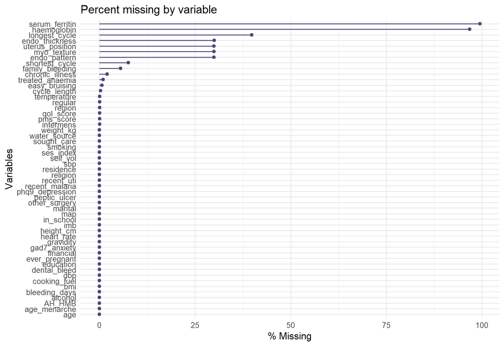

```r
gg_miss_var(dat, show_pct = TRUE) + labs(title = "Percent missing by variable")
```

# 7 Variable consistency checks

Logical rules that should hold for every record. Violations flag data-entry problems.

```r
rule <- function(name, ok) {
  bad <- sum(!ok, na.rm = TRUE); n <- sum(!is.na(ok))
  tibble(Check = name, Evaluable = n, Violations = bad,
         `% violating` = if (n) round(100 * bad / n, 1) else NA_real_)
}
cons <- bind_rows(
  rule("Age at menarche < current age", dat$age_menarche < dat$age),
  rule("Longest bleeding >= shortest bleeding", dat$longest_cycle >= dat$shortest_cycle),
  rule("Active bleeding days <= cycle length", dat$bleeding_days <= dat$cycle_length),
  rule("Systolic BP >= diastolic BP", dat$sbp >= dat$dbp),
  rule("BMI within 12-60", dat$bmi >= 12 & dat$bmi <= 60),
  rule("Heart rate within 40-160", dat$heart_rate >= 40 & dat$heart_rate <= 160)
)
cons %>% gt() %>% tab_header(title = "Variable consistency checks") %>%
  data_color(columns = Violations, fn = scales::col_numeric(c("white", CORAL),
             domain = c(0, max(1, max(cons$Violations, na.rm = TRUE)))))
```

Variable consistency checks

| Check | Evaluable | Violations | % violating |
| --- | --- | --- | --- |
| Age at menarche < current age | 1055 | 8 | 0.8 |
| Longest bleeding >= shortest bleeding | 632 | 5 | 0.8 |
| Active bleeding days <= cycle length | 1052 | 0 | 0.0 |
| Systolic BP >= diastolic BP | 1055 | 0 | 0.0 |
| BMI within 12-60 | 1055 | 0 | 0.0 |
| Heart rate within 40-160 | 1055 | 0 | 0.0 |

# 8 Plots of key variables versus the outcome

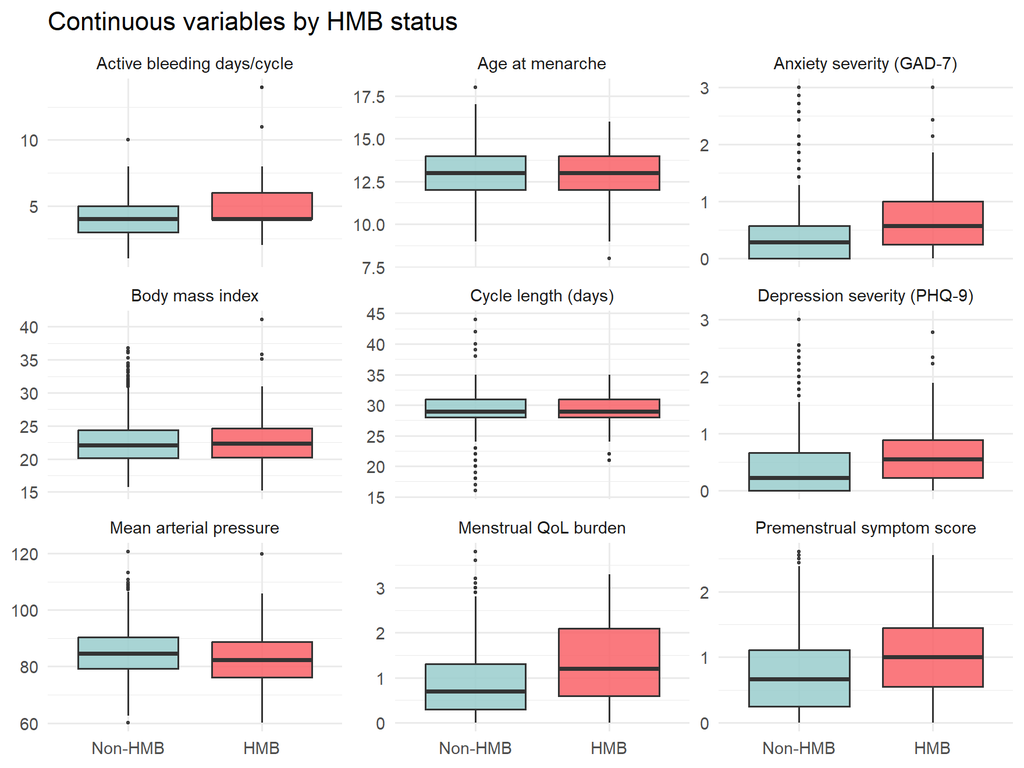

```r
cont_keys <- intersect(c("bleeding_days","age_menarche","cycle_length","bmi","map",
                         "phq9_depression","gad7_anxiety","pms_score","qol_score"), names(dat))
dat %>%
  select(AH_HMB, all_of(cont_keys)) %>%
  pivot_longer(-AH_HMB) %>%
  mutate(name = recode(name, !!!var_labels)) %>%
  ggplot(aes(AH_HMB, value, fill = AH_HMB)) +
  geom_boxplot(alpha = 0.85, outlier.size = 0.6) +
  facet_wrap(~ name, scales = "free_y") +
  scale_fill_manual(values = c("Non-HMB" = "#9CC", "HMB" = CORAL), guide = "none") +
  labs(x = NULL, y = NULL, title = "Continuous variables by HMB status")
```

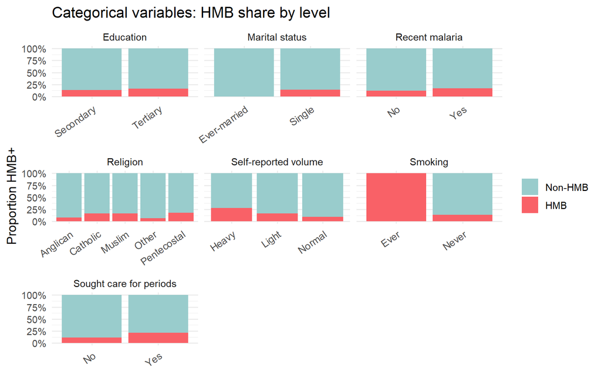

```r
cat_keys <- intersect(c("self_vol","marital","religion","education","smoking",
                        "recent_malaria","sought_care","dysmenorrhea"), names(dat))
dat %>%
  select(AH_HMB, all_of(cat_keys)) %>%
  pivot_longer(-AH_HMB, values_transform = as.character) %>%
  filter(!is.na(value)) %>%
  mutate(name = recode(name, !!!var_labels)) %>%
  count(name, value, AH_HMB) %>%
  group_by(name, value) %>% mutate(prop = n / sum(n)) %>% ungroup() %>%
  ggplot(aes(value, prop, fill = AH_HMB)) +
  geom_col(position = "fill") +
  facet_wrap(~ name, scales = "free_x") +
  scale_fill_manual(values = c("Non-HMB" = "#9CC", "HMB" = CORAL), name = NULL) +
  scale_y_continuous(labels = scales::percent) +
  labs(x = NULL, y = "Proportion HMB+", title = "Categorical variables: HMB share by level") +
  theme(axis.text.x = element_text(angle = 35, hjust = 1))
```

# 9 Univariate logistic associations

One logistic regression per variable (outcome = HMB), giving the crude odds ratio, 95% CI and p-value. Variables with too little data for a stable fit are dropped automatically.

```r
enough <- function(v) {
  x <- dat[[v]]; ok <- !is.na(x) & !is.na(dat$AH_HMB)
  if (sum(ok) < 30) return(FALSE)
  if (is.numeric(x)) return(length(unique(x[ok])) > 1)
  tab <- table(droplevels(factor(x[ok])), dat$AH_HMB[ok])
  nrow(tab) > 1 && all(colSums(tab) > 0) && min(tab) >= 1
}
# One univariate logistic per variable; odds ratio with Wald 95% CI (fast and stable).
uni_one <- function(v) {
  d <- dat %>% select(AH_HMB, all_of(v)) %>% filter(!is.na(.data[[v]]), !is.na(AH_HMB))
  fit <- tryCatch(glm(AH_HMB ~ ., data = d, family = binomial), error = function(e) NULL)
  if (is.null(fit)) return(NULL)
  td <- tryCatch(broom::tidy(fit), error = function(e) NULL)
  if (is.null(td)) return(NULL)
  td %>%
    filter(term != "(Intercept)") %>%
    mutate(
      level = if (is.numeric(d[[v]])) "" else sub(v, "", term, fixed = TRUE),
      Predictor = if_else(level == "", lab_of(v), paste0(lab_of(v), ": ", level)),
      OR = exp(estimate),
      lo = exp(estimate - 1.96 * std.error),
      hi = exp(estimate + 1.96 * std.error)
    ) %>%
    transmute(Predictor,
              `OR` = sprintf("%.2f", OR),
              `95% CI` = sprintf("%.2f - %.2f", lo, pmin(hi, 9999)),
              `p` = fmt_p(p.value), p_num = p.value)
}
uni_table <- function(vars, caption) {
  vars <- vars[map_lgl(vars, enough)]
  res <- purrr::map_dfr(vars, uni_one)
  if (!nrow(res)) return(gt(tibble(Note = "No variable had enough data for a stable fit.")))
  res %>%
    gt() %>%
    tab_header(title = caption) %>%
    cols_hide(p_num) %>%
    tab_style(style = cell_text(weight = "bold"),
              locations = cells_body(columns = `p`, rows = p_num < 0.05)) %>%
    tab_options(table.font.size = px(12), data_row.padding = px(3))
}
```

## 9.1 Demographics and social

```r
uni_table(c(domains[["Demographics"]], domains[["Social history"]]),
          "Univariate associations: demographics and social history")
```

Univariate associations: demographics and social history

| Predictor | OR | 95% CI | p |
| --- | --- | --- | --- |
| Age (years) | 1.01 | 0.92 - 1.12 | 0.786 |
| Region: Eastern | 1.13 | 0.53 - 2.42 | 0.758 |
| Region: Northern | 1.33 | 0.52 - 3.42 | 0.558 |
| Region: Other | 5.44 | 1.02 - 28.87 | 0.047 |
| Region: Western | 3.22 | 0.80 - 12.94 | 0.099 |
| Residence: Semi-urban | 0.97 | 0.59 - 1.60 | 0.904 |
| Residence: Urban | 1.27 | 0.80 - 2.03 | 0.315 |
| Currently in school: Yes | 0.16 | 0.02 - 1.15 | 0.069 |
| Education: Tertiary | 1.24 | 0.62 - 2.51 | 0.545 |
| Religion: Catholic | 2.31 | 1.36 - 3.94 | 0.002 |
| Religion: Muslim | 2.42 | 1.45 - 4.05 | <0.001 |
| Religion: Other | 0.80 | 0.10 - 6.30 | 0.830 |
| Religion: Pentecostal | 2.64 | 1.49 - 4.68 | <0.001 |
| Socioeconomic status (PCA) | 0.83 | 0.74 - 0.92 | <0.001 |
| Alcohol use: Never | 0.43 | 0.23 - 0.80 | 0.007 |
| Drinking water source: Other | 1.02 | 0.59 - 1.76 | 0.946 |
| Drinking water source: Piped water | 1.04 | 0.68 - 1.60 | 0.850 |
| Cooking fuel: Fire wood | 0.96 | 0.58 - 1.59 | 0.875 |
| Cooking fuel: Other | 1.63 | 1.09 - 2.44 | 0.018 |
| Financial difficulty (0-4) | 0.98 | 0.82 - 1.18 | 0.856 |

## 9.2 Obstetrics, gynaecology and medical history

```r
uni_table(c(domains[["Obstetrics & gynaecology"]], domains[["Medical history"]]),
          "Univariate associations: obstetrics, gynaecology and medical history")
```

Univariate associations: obstetrics, gynaecology and medical history

| Predictor | OR | 95% CI | p |
| --- | --- | --- | --- |
| Age at menarche | 0.81 | 0.71 - 0.92 | 0.002 |
| Cycle length (days) | 0.99 | 0.94 - 1.04 | 0.582 |
| Regular monthly periods: Yes | 0.45 | 0.16 - 1.27 | 0.130 |
| Active bleeding days/cycle | 1.59 | 1.39 - 1.82 | <0.001 |
| Days between periods | 0.99 | 0.94 - 1.05 | 0.791 |
| Longest bleeding (days) | 0.89 | 0.82 - 0.97 | 0.011 |
| Shortest bleeding (days) | 0.99 | 0.94 - 1.04 | 0.559 |
| Intermenstrual spotting: Yes | 1.73 | 1.06 - 2.85 | 0.030 |
| Self-reported volume: Normal | 0.55 | 0.29 - 1.02 | 0.058 |
| Self-reported volume: Heavy | 1.99 | 1.05 - 3.79 | 0.036 |
| Number of pregnancies | 12.41 | 1.12 - 137.75 | 0.040 |
| Ever pregnant: Yes | 12.41 | 1.12 - 137.75 | 0.040 |
| Chronic illness: Yes | 3.03 | 1.53 - 5.99 | 0.001 |
| Recent malaria: Yes | 1.49 | 1.04 - 2.11 | 0.028 |
| Recent UTI: Yes | 1.42 | 0.90 - 2.25 | 0.132 |
| Peptic ulcer: Yes | 1.29 | 0.86 - 1.94 | 0.224 |
| Bleeding after dental work: Yes | 3.00 | 2.10 - 4.27 | <0.001 |
| Bleeding after surgery: Yes | 1.97 | 0.78 - 5.03 | 0.154 |
| Easy bruising/nosebleeds: Yes | 1.51 | 0.97 - 2.33 | 0.066 |
| Sought care for periods: Yes | 2.21 | 1.54 - 3.17 | <0.001 |

## 9.3 Clinical, ultrasound, laboratory and mental health

```r
uni_table(c(domains[["Clinical measurements"]], domains[["Ultrasound"]],
            domains[["Laboratory"]], domains[["Mental health & QoL"]]),
          "Univariate associations: clinical, ultrasound, laboratory and mental health")
```

Univariate associations: clinical, ultrasound, laboratory and mental health

| Predictor | OR | 95% CI | p |
| --- | --- | --- | --- |
| Body mass index | 1.02 | 0.97 - 1.07 | 0.507 |
| Weight (kg) | 1.01 | 0.99 - 1.02 | 0.549 |
| Height (cm) | 1.00 | 0.97 - 1.03 | 0.823 |
| Systolic BP (mmHg) | 0.97 | 0.96 - 0.99 | 0.002 |
| Diastolic BP (mmHg) | 0.97 | 0.95 - 0.99 | 0.001 |
| Mean arterial pressure | 0.96 | 0.94 - 0.98 | <0.001 |
| Heart rate (bpm) | 1.00 | 0.98 - 1.01 | 0.933 |
| Temperature (C) | 1.07 | 0.72 - 1.59 | 0.730 |
| Endometrial thickness (mm) | 1.04 | 0.98 - 1.11 | 0.212 |
| Uterine position: Others | 0.72 | 0.09 - 5.78 | 0.760 |
| Uterine position: Retroverted | 0.52 | 0.20 - 1.32 | 0.168 |
| Haemoglobin (g/dL) | 0.91 | 0.61 - 1.37 | 0.653 |
| Depression severity (PHQ-9) | 2.19 | 1.59 - 3.02 | <0.001 |
| Anxiety severity (GAD-7) | 2.08 | 1.57 - 2.76 | <0.001 |
| Premenstrual symptom score | 2.14 | 1.61 - 2.84 | <0.001 |
| Menstrual QoL burden | 2.07 | 1.68 - 2.56 | <0.001 |

# 10 Notes and caveats

- The laboratory block (CBC, iron panel, hormones) is largely not yet collected in this cohort, so those rows show high missingness; they are kept for completeness and will populate as data accrue.
- Several predictors are symptoms or consequences of HMB (self-reported volume, treated for anaemia, prolonged bleeding). They are appropriate for a symptom-based description but should be read with care when inferring causes.
- Univariate associations are unadjusted. Variables that perfectly separate the outcome give unstable odds ratios; the multivariable and LASSO modelling (the Python pipeline) handles those formally.

```
## R version: R version 4.5.2 (2025-10-31 ucrt)
```

```
## Key packages: gt 1.3.0 | dplyr 1.1.4 | naniar 1.1.0
```